# Part II - Ford GoBike System Data Analysis

## Investigation Overview

Goals:

1. Finding the average distance travelled by renters
2. Finding the average rent duration by renters
3. Finding which renter type and gender that usually rent the bikes out for longer
4. Exploring the relationships of distance, age and rent duration by gender and renter type

## Dataset Overview and Executive Summary

The dataset contains information about bike rentals and renters in the San Franciso area.

Insights:

1. It was found that travelled distances were usually between 0.25 km and 2.75 km.
2. It was found that bikes were rented for around 200-800 most of the time.
3. It was found that for age and distance, neither the renter type nor the renter gender affected them, but for the duration it was found that females tended to rent out bikes longer as well as customers (not subscribers) rented out bikes longer.

```python
# import all packages and set plots to be embedded inline
import numpy as np
import pandas as pd
import matplotlib.pyplot as plt
import seaborn as sns

# suppress warnings from final output
import warnings
warnings.simplefilter("ignore")

%config InlineBackend.figure_format='retina'
```

```python
df = pd.read_csv('cleaned.csv')
```

## Distribution of Distance

The visualization shows the distribution of distance travelled by bikes during their renting period. The graph shows that most bikes travelled between 0.25 km and 2.75 km.

> **Rubric Tip**: Provide at least 3 **polished** visualizations to convey key insights. The total number of visualizations shoould be less than 50% of the number of visualizations in the exploratory analysis. Generally 3-5 visualizations suffice.

> **Rubric Tip**: Each visualization in the slideshow is associated with **descriptive comments** that accurately depict their purpose and your observation.

> **Rubric Tip**: All plots shown are appropriate, meaning the plot type, encodings, and transformations are suitable to the underlying data.

> **Rubric Tip**: All plots in the slideshow are polished, meaning all plots have a title, labeled x/y axes (with units), x/y ticks, and legends.

```
''
```

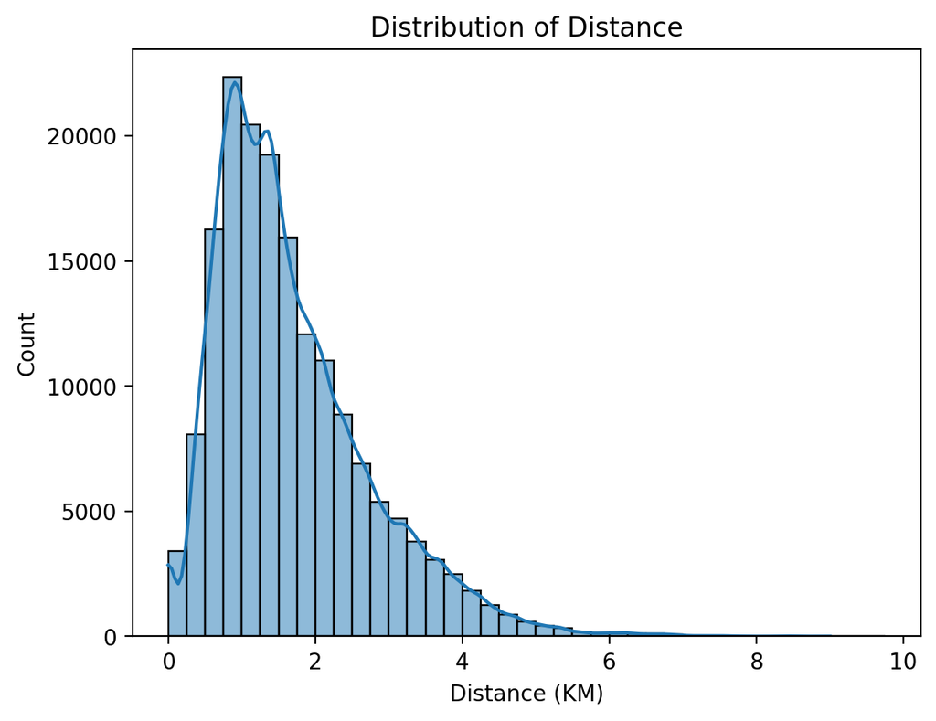

```python
bins = np.arange(np.around(df['distance'].min()),10, 0.25)
ax = sns.histplot(df, x='distance',bins=bins,kde=True, kde_kws=dict(clip=(bins.min(), bins.max())))
ax.set_title('Distribution of Distance')
ax.set_xlabel('Distance (KM)')
;
```

## Distribution of Duration

The visualization shows the distribution of rent duration. It was found that bikes were rented for around 200-800 most of the time.

```
''
```

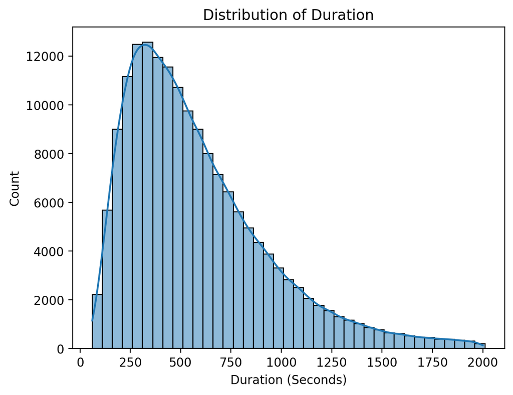

```python
bins = np.arange(np.around(df['duration_sec'].min()),2000+50, 50)
ax = sns.histplot(df, x='duration_sec',bins=bins,kde=True, kde_kws=dict(clip=(bins.min(), bins.max())))
ax.set_title('Distribution of Duration')
ax.set_xlabel('Duration (Seconds)')
;
```

## Box Plots of Age, Distance and Duration by Gender and Renter Type

The visualization shows box plots of age, distance and duration where each two of these three variables are plotted on either the x or y axis with the boxes within the plot being gender or renter type. It was found that for age and distance, neither the renter type nor the renter gender affected them, but for the duration it was found that females tended to rent out bikes longer as well as customers (not subscribers) rented out bikes longer.

```
''
```

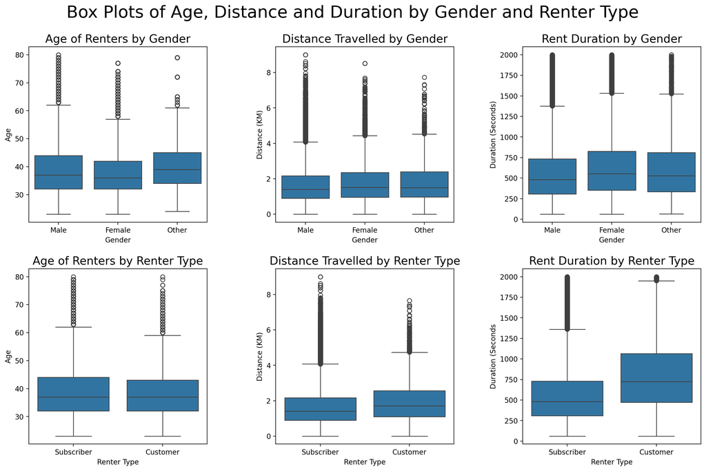

```python
fig, axes = plt.subplots(2,3);

fig.tight_layout(rect=[0, 0.03, 1, 0.94])

fig.suptitle("Box Plots of Age, Distance and Duration by Gender and Renter Type",fontsize=24);
fig.set_size_inches(15, 10);


sns.boxplot(df,x='member_gender',y='age',ax=axes[0][0]);

sns.boxplot(df,x='member_gender',y='distance',ax=axes[0][1]);

sns.boxplot(df,x='member_gender',y='duration_sec',ax=axes[0][2]);

sns.boxplot(df,x='user_type',y='age',ax=axes[1][0]);

sns.boxplot(df,x='user_type',y='distance',ax=axes[1][1]);

sns.boxplot(df,x='user_type',y='duration_sec',ax=axes[1][2]);


axes[0][0].set_title("Age of Renters by Gender",fontsize=16);
axes[0][0].set_xlabel("Gender");
axes[0][0].set_ylabel("Age");

axes[0][1].set_title("Distance Travelled by Gender",fontsize=16);
axes[0][1].set_xlabel("Gender");
axes[0][1].set_ylabel("Distance (KM)");

axes[0][2].set_title("Rent Duration by Gender",fontsize=16);
axes[0][2].set_xlabel("Gender");
axes[0][2].set_ylabel("Duration (Seconds)");

axes[1][0].set_title("Age of Renters by Renter Type",fontsize=16);
axes[1][0].set_xlabel("Renter Type");
axes[1][0].set_ylabel("Age");

axes[1][1].set_title("Distance Travelled by Renter Type",fontsize=16);
axes[1][1].set_xlabel("Renter Type");
axes[1][1].set_ylabel("Distance (KM)");

axes[1][2].set_title("Rent Duration by Renter Type",fontsize=16);
axes[1][2].set_xlabel("Renter Type");
axes[1][2].set_ylabel("Duration (Seconds");
;
```

## Bike Rent Duration by Renter Type then Gender

This visualization further explores what was found in the previous visualization showing just by how much more bikes are rented for by each group.

```
''
```

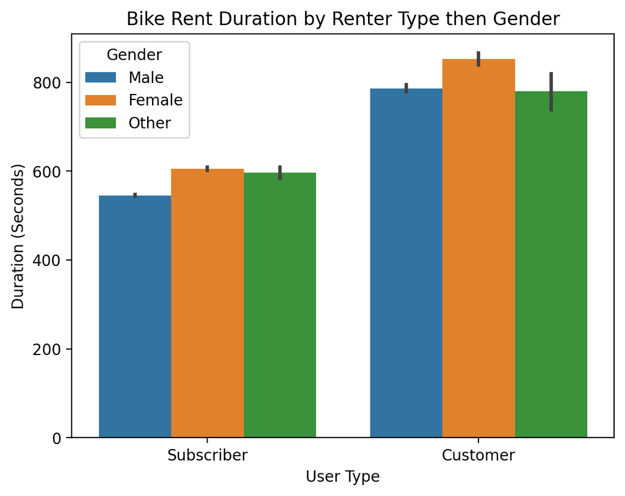

```python
ax = sns.barplot(df, x='user_type',y='duration_sec',hue='member_gender');
ax.set_title('Bike Rent Duration by Renter Type then Gender')
ax.set_ylabel('Duration (Seconds)')
ax.set_xlabel('User Type')
ax.legend(title='Gender')
;
```

### Submission

If you are using classroom workspace, you can choose from the following two ways of submission:

1. **Submit from the workspace**. Make sure you have removed the example project from the /home/workspace directory. You must submit the following files:
   - Part_I_notebook.ipynb
   - Part_I_notebook.html or pdf
   - Part_II_notebook.ipynb
   - Part_II_notebook.html or pdf
2. **Submit a zip file on the last page of this project lesson**. In this case, open the Jupyter terminal and run the command below to generate a ZIP file.

```
zip -r my_project.zip .
```

The command abobve will ZIP every file present in your /home/workspace directory. Next, you can download the zip to your local, and follow the instructions on the last page of this project lesson.